Taipei 2 Market Analysis

# 進口水果年度總量分析：台北二市場版

這份報告是原專題的市場限定版本，將 AMIS 查詢條件鎖定為 **104 台北二**，觀察民國 105 年 1 月到民國 115 年 5 月之間， 47 項指定進口水果在台北二市場的交易量變化。 這一版刻意把分析化約成「每年的總量」與「固定月份的跨年總量比較」， 不再以增減率作為主分析架構。

資料導讀

## 資料結構、獲取方式與資料量

本研究使用的是 AMIS 台北二市場 (`104 台北二`) 的水果行情比較報表， 時間範圍從民國 `105年01月上旬` 到 `115年05月下旬`，時間粒度是「旬」， 也就是每個月分成上旬、中旬、下旬三期。價格單位為 **元/公斤**， 進口量與交易量單位為 **公斤**。

原始資料是透過 AI 撰寫的爬蟲，自動向 AMIS `FruitProdTransInfoCP.aspx` 逐期送出查詢條件，抓取 47 項指定進口水果的比較報表，總共取得 `375` 份 `.xls` 檔。 每份報表都包含本期、上期、市場、產品、平均價格與交易量等欄位。

清理後的主要變數欄位包括： `current_period_label`、`current_period_token`、`product_code`、`product_full_name`、 `avg_price_current`、`avg_price_previous`、`avg_price_diff`、`avg_price_change_rate`、 `trade_volume_current`、`trade_volume_previous`、`trade_volume_diff`、`trade_volume_change_rate`。 其中 `observed` 長表保留實際出現在報表中的資料，共 `9,209` 筆； `panel` 完整表補齊全部 `375 期 × 47 品項` 的組合，共 `17,625` 筆； `period summary` 則整理成 `375` 筆期數摘要，用來記錄每一期實際觀測到多少產品。

專題設定

## 這份 REPORT2 的用途

原本的 `REPORT.html` 是全市場版本，`REPORT2.html` 則專門記錄台北二市場結果， 讓同一個研究題目可以同時保留「全市場」與「單一市場」兩個分析視角，不把不同查詢條件的結論混在一起。

描述統計

## 台北二主要進口水果與近五年進口量

先用最基本的描述統計看台北二市場的主力品項。以下表格列出累積交易量最高的 5 種進口水果， 並整理近五年完整年度 `110年` 到 `114年` 的每年進口量，方便直接看出台北二市場近年的核心結構。

| 主要進口水果 | 110年 | 111年 | 112年 | 113年 | 114年 |
| --- | --- | --- | --- | --- | --- |
| X69 蘋果 富士進口 | 5,556,658 | 4,910,245 | 4,788,234 | 5,358,423 | 5,294,683 |
| G49 奇異果 進口 | 1,069,519 | 968,629 | 860,410 | 1,017,390 | 922,309 |
| E9 甜橙 進口 | 530,574 | 601,534 | 558,265 | 442,131 | 812,024 |
| S49 葡萄 無子進口 | 653,548 | 700,173 | 705,938 | 621,095 | 744,706 |
| 839 櫻桃 進口 | 479,615 | 531,696 | 490,105 | 516,476 | 718,933 |

資料來源

## 台北二版本的查詢規格

- 查詢頁面：AMIS 水果行情 `FruitProdTransInfoCP.aspx`
- 市場條件：`104 台北二`
- 日期別：旬
- 時間範圍：民國 105 年 1 月至民國 115 年 5 月
- 查詢批次：每月上旬、中旬、下旬，共 375 期
- 產品範圍：47 個指定進口水果代碼

資料成果

## 台北二市場的整理結果

- 原始檔案：375 個台北二市場 `.xls` 報表
- 觀測資料表：9,209 筆實際出現的產品-旬別資料
- 完整 panel：17,625 筆（375 期 × 47 產品）
- 期數摘要表：375 筆
- 台北二版的最末期 `115年05月下旬` 不是空資料期，實際觀測到 24 個產品

分析方法

## 改用年度總量作為主分析軸

這份報告不再把「旬增減率」當成主分析方法，而是直接把 每一期的 `trade_volume_current` 加總成年度總交易量， 用最直觀的描述統計觀察台北二市場的量體變化。

除了年度總量之外，我也保留兩個輔助角度： 一是每年交易量最高的主力水果，二是固定比較 `2月、5月、8月、11月` 的跨年總量，用來檢查季節節奏是否穩定。

另外新增一個簡化指標：**價格量比 = 加權平均價格 ÷ 每萬公斤總量**。 這個指標不是在看漲跌率，而是在固定月份下，同時考慮價格與進口量， 用來觀察「量少但價格高」或「量大但價格相對低」的市場狀態。

主要發現

## 台北二市場的年度總量結果

### 完整年度總量最高在 105 年

如果只看完整年度，台北二市場總交易量最高的是 `105年`，約 `1,294.2` 萬公斤；之後整體大致落在 `1,030` 到 `1,218` 萬公斤之間。

### 112 年是完整年度低點

`112年` 的總交易量最低，約 `1,033.9` 萬公斤；到了 `114年` 又回升到約 `1,183.8` 萬公斤，顯示台北二市場近年量體先降後回升。

### 115 年目前只到 5 月

`115年` 現在只有 `401.6` 萬公斤，不能和完整年度直接相比，因為這批資料只涵蓋到 `115年05月下旬`。

### 奇異果長期是第二主力

`G49 奇異果 進口` 幾乎每年都排在第二，代表台北二市場的進口水果量能不是平均分散，而是高度集中在固定幾個核心品項。

### 固定月份比較仍是 8 月最旺

若固定比較 `2月、5月、8月、11月`，跨年平均總量最高的是 `8月`，約 `116.6` 萬公斤，其次是 `5月`，最低則是 `2月`，顯示台北二市場同樣存在夏季較旺、冬末較弱的節奏。

### 價格量比以 2 月最高

若改看新指標 `價格量比`，跨年平均最高的是 `2月`，平均約 `1.32`；最低則是 `5月`，平均約 `0.69`。這代表 2 月常出現「總量較小但單位價格較高」的組合，而 5 月更接近「量較大、價格較平」的市場狀態。

### 極端值出現在 108 年 2 月

完整年度中價格量比最高的是 `108年2月`，約 `1.73`；最低的是 `109年5月`，約 `0.52`。這兩個點很適合拿來對照量縮高價與量增平價的市場差異。

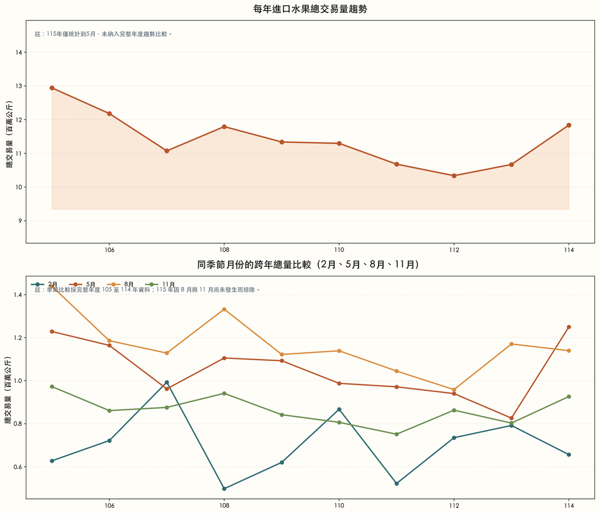

圖 1 是這份簡化版報告的核心。上半部直接顯示台北二市場每年的總交易量，下半部則固定比較 `2月、5月、8月、11月` 的跨年總量變化，因此整份分析可以完全建立在總量描述統計上。

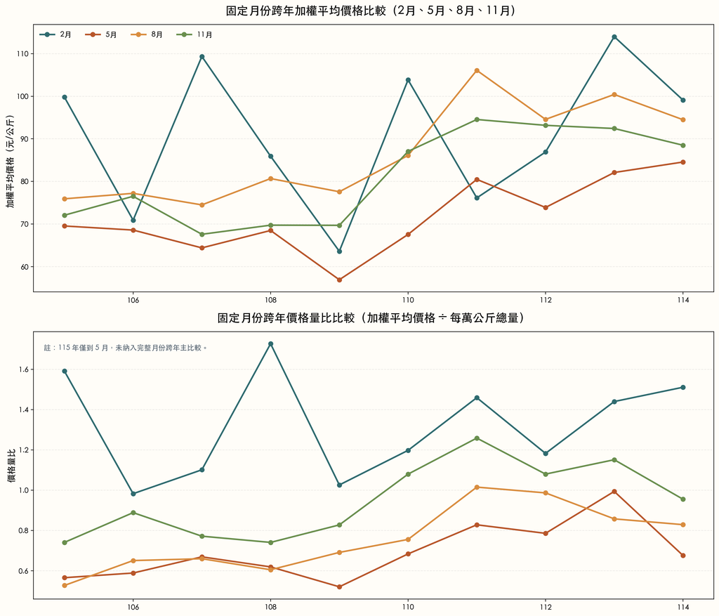

圖 2 補充新的 `價格：進口量` 指標。上半部是固定月份的跨年加權平均價格，下半部則是價格量比 `加權平均價格 ÷ 每萬公斤總量`。這張圖能在不使用增減率的前提下，把價格與進口量一起納入比較。

Top 5 分析

## 主力水果分開看

若把台北二市場的主力水果拆開來看，會更容易分辨「誰是量體最大」和「誰的價格相對於進口量更高」。 因此這裡另外補兩張折線圖：第一張看完整期間的年進口量，第二張看同一批水果在完整期間的價格/進口量指數。

### X69 蘋果 富士進口

這是台北二市場最穩定的最大宗品項，累積進口量約 `5,685.7` 萬公斤。近五年雖然不像 `105年` 那麼高，但每年都維持在 `478` 到 `556` 萬公斤之間，說明它是台北二市場的長期核心主力。

### G49 奇異果 進口

奇異果幾乎每年都排在第二名，累積進口量約 `1,111.9` 萬公斤。近五年從 `106.9` 萬公斤逐步滑落到 `92.2` 萬公斤，中間在 `113年` 一度回升，屬於量體大但有些微波動的第二主力。

### E9 甜橙 進口

甜橙的長期累積量約 `680.5` 萬公斤。它不像蘋果富士那樣穩定，`110年` 到 `113年` 曾壓在 `44` 到 `60` 萬公斤之間，但 `114年` 跳升到 `81.2` 萬公斤，是近五年成長最明顯的品項之一。

### S49 葡萄 無子進口

無子葡萄累積量約 `617.6` 萬公斤，近五年都維持在 `62` 到 `74` 萬公斤之間，波動幅度不算特別大。`114年` 的 `74.5` 萬公斤是這個品項的高點，顯示近年仍有擴大量能的趨勢。

### 839 櫻桃 進口

櫻桃累積量約 `563.3` 萬公斤，近五年的年量大多在 `48` 到 `53` 萬公斤左右，但 `114年` 明顯拉高到 `71.9` 萬公斤。這代表它雖然不是最大宗主力，卻是近年相對有成長動能的品項。

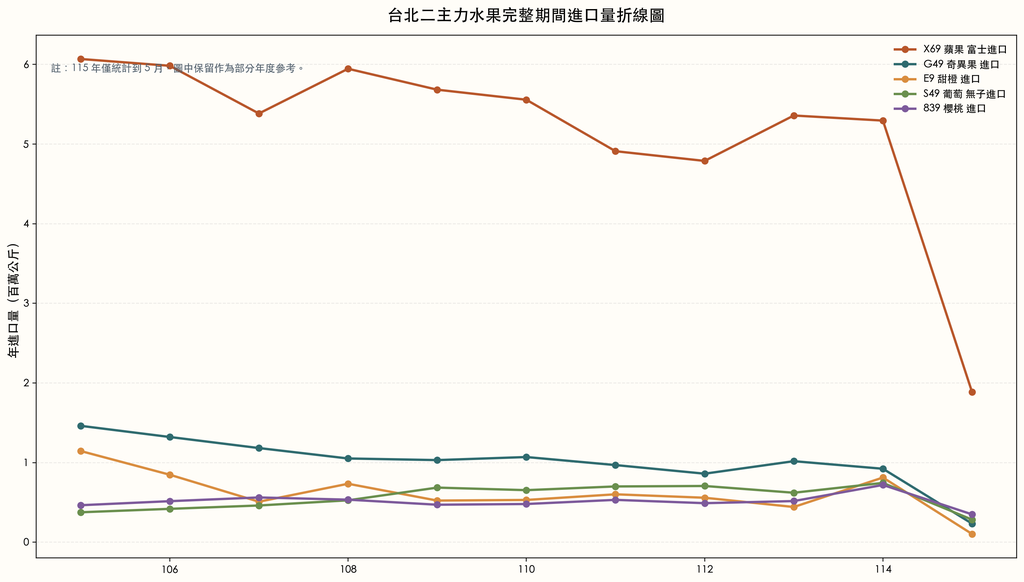

圖 3 把五個主力水果在 `105年` 到 `115年` 的完整期間進口量拆開比較。`X69 蘋果 富士進口` 的量體遠高於其他水果，幾乎形成單獨一個級距；第二梯隊是 `G49 奇異果 進口`，而 `甜橙`、`無子葡萄`、`櫻桃` 則落在更接近的中小量體區間。圖中的 `115年` 只到 5 月，因此可視為部分年度參考。

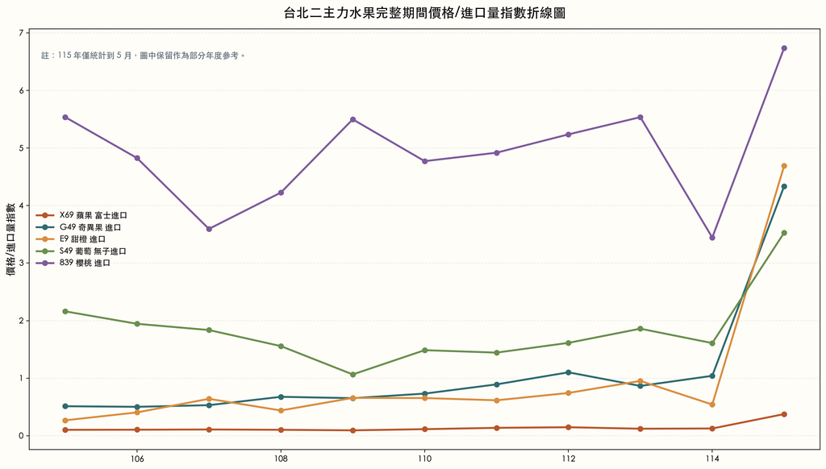

圖 4 則改看主力水果在完整期間的價格/進口量指數。這張圖和進口量圖形成對照：`839 櫻桃 進口` 的量不算最大，但因價格高、量相對小，所以指數長期偏高；`X69 蘋果 富士進口` 則因量非常大，指數長期維持在最低檔，顯示它是典型的大量平價主力品項。`115年` 同樣只代表前 5 個月的部分年度狀態。

資料限制

## 閱讀台北二結果時要注意什麼

- 這份版本刻意不使用增減率，因此它更適合回答「市場量體大小」與「年度結構變化」，不適合直接回答短期價格震盪問題。
- 台北二版的 `115年` 只有到 5 月，不能和 `105年` 到 `114年` 的完整年度直接並列解讀。
- 台北二版的 `115年05月下旬` 不是空白期，表示市場限定之後，最後一期的資料狀況與全市場不同。
- 若要進一步解釋為何某些水果只在台北二市場零星出現，仍需搭配市場分工、貨源配置或通路背景資料。

結論

## 台北二市場版的總量結論

如果把分析化約成每年的總量，台北二市場最明顯的特徵有三個： 第一，整體量體在完整年度間大致落在 `1,000` 到 `1,300` 萬公斤； 第二，`105年` 是高點、`112年` 是低點、`114年` 有回升； 第三，市場量能長期集中在 `X69 蘋果 富士進口` 與 `G49 奇異果 進口` 這類主力水果。

再加上 `價格量比` 之後，這份報告雖然不使用增減率，仍然可以補到價格面訊號。 若你要交作業或做簡報，用「年度總量 + 固定月份價格量比」來講台北二市場， 會比直接談短期漲跌更穩定，也更容易解釋。